# Statistical Inference – Part 1

[Ryan Lei](https://www.coursera.org/user/i/adc3888c696d25d769137c26e7006fd8)

January 25, 2015

### Introduction

In this exercise, we will explore the distribution of the **averages** of 40 exponential random variables and compare it with the distribution of only 1 exponential random variable.

### Properties of A Single Exponential Random Variable

- parameter: $\lambda$ (set to **0.2** for the whole exercise)
- probability density function: $f(x;\lambda) = \lambda \exp^{-\lambda x}$ for $x >= 0$
- mean: 1 / $\lambda$
- standard deviation: 1 / $\lambda$
- variance: 1 / $\lambda^2$

### Result of 1,000 Simulations

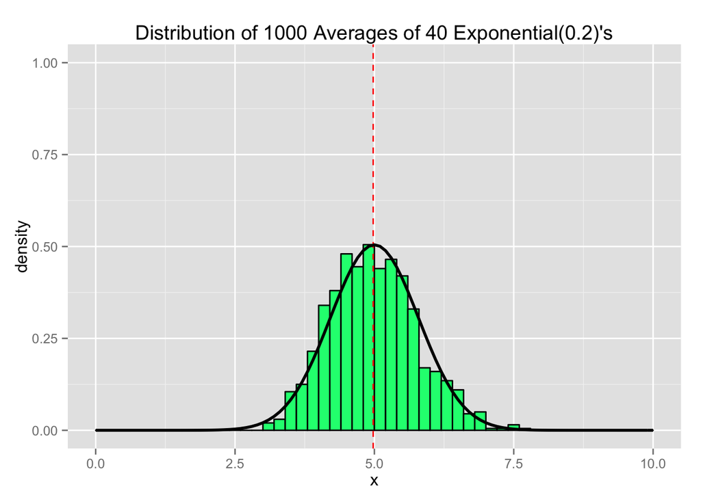

```r
# Code modified from the instructor's Rmd lecture file on topic 07: Asymptopia
library(ggplot2)
lambda <- 0.2  # pamaeter in exponential random variables
nosim <- 1000  # number of simulations
size <- 40    # sample size

# Put the rexp values in a matrix of nosim (1000) rows and size (40 or 1) columns.
# Then, take the mean over each row.
dat_avg <- data.frame(x = apply(matrix(rexp(size * nosim, lambda), nosim), 1, mean))
dat_one <- data.frame(x = apply(matrix(rexp( 1 * nosim, lambda), nosim), 1, mean))

# Plot for size = 40 and its approximated normal distribution
ggplot(dat_avg, aes(x)) + geom_histogram(binwidth = 0.2, color = "black",
    fill = "springgreen", aes(y = ..density..)) +
    geom_vline(xintercept = mean(dat_avg$x), color = "red", linetype = "dashed") +
    stat_function(fun = dnorm, size = 1, color = "black",
        args = list(mean = 1 / lambda, sd = 1 / (lambda * sqrt(size)))) +
    xlim(0, 10) + ylim(0, 1) +
    labs(title = paste("Distribution of ", nosim, " Averages of ", size,
        " Exponential(", lambda, ")'s", sep = ""))
```

The *simulated* mean (shown in **red** dashed lines) and variance are:

```r
c(mean(dat_avg$x), var(dat_avg$x))
```

```
## [1] 4.9784039 0.6177909
```

The *theoretical* mean $1 / \lambda$ and variance $\sigma^2 / n = 1 / (\lambda^2 \cdot n)$ are:

```r
c(1 / lambda, 1 / (lambda ^ 2 * size))
```

```
## [1] 5.000 0.625
```

### Explanation

The simulated distribution is shown in **green**. From the numbers, we can see both the mean and variance of the simulated data are quite close to the theoretical mean and variance.

If we overlap another normal distribution (shown in **black**) of mean = $1 / \lambda$ and variance = $1 / (\lambda^2 \cdot n)$, the distribution of averages of 40 exponentials can sufficiently approximate normal for sample size n = 40.

### Comparison with The Distribution of Only 1 Exponential

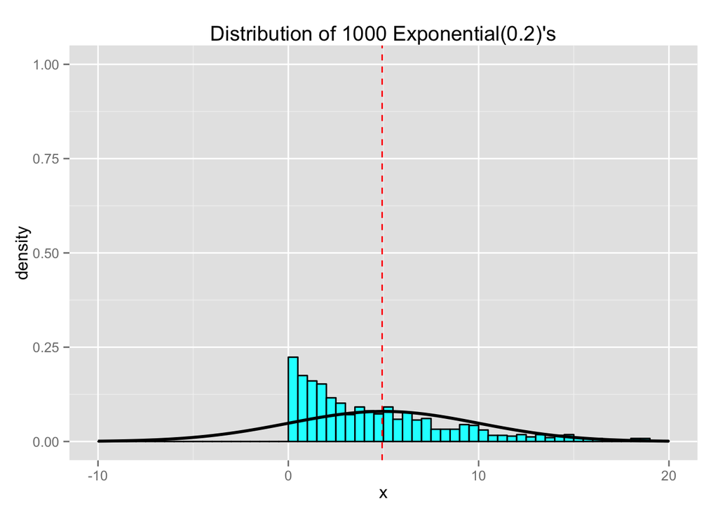

```r
# Plot for size = 1 and its approximated normal distribution
ggplot(dat_one, aes(x)) + geom_histogram(binwidth = 0.5, color = "black",
    fill = "cyan", aes(y = ..density..)) +
    geom_vline(xintercept = mean(dat_one$x), color = "red", linetype = "dashed") +
    stat_function(fun = dnorm, size = 1, color = "black",
        args = list(mean = 1 / lambda, sd = 1 / (lambda * sqrt(1)))) +
    xlim(-10, 20) + ylim(0, 1) +
    labs(title = paste("Distribution of ", nosim,
        " Exponential(", lambda, ")'s", sep = ""))
```

The *simulated* mean (shown in **red** dashed lines) and variance are:

```r
c(mean(dat_one$x), var(dat_one$x))
```

```
## [1]  4.930201 23.445062
```

The *theoretical* mean $1 / \lambda$ and variance $\sigma^2 / n = 1 / (\lambda^2 \cdot n)$ are:

```r
c(1 / lambda, 1 / (lambda ^ 2 * 1))
```

```
## [1]  5 25
```

When the sample size n = 1, although the simulated mean and variance are still close to the theoretical values, the shape of the distribution (shown in **cyan**) is far from normal. The density decays over x.

### Conclusion

The Central Limit Theorem gives **no garentee** about the performance in *finite* sample sizes. Therefore, in this exercise, it is enough for the distribution of averages of exponential(0.2)’s to approximate *normal* for a sample size n = 40, but NOT enough for n = 1.